# survival lecture 6

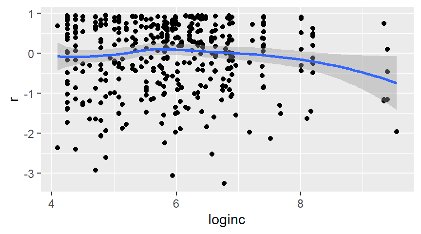

```r
ggplot(leader, aes(loginc, r))   +
  geom_point()                   +
  geom_smooth(se=TRUE)
```

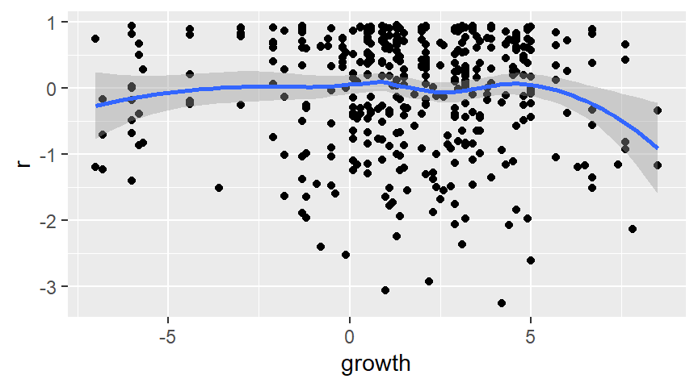

```r
ggplot(leader, aes(growth, r))   +
  geom_point()                   +
  geom_smooth(se=TRUE)
```

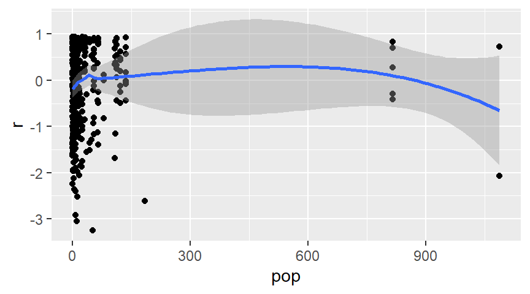

```r
ggplot(leader, aes(pop, r))      +
  geom_point()                   +
  geom_smooth(se=TRUE)
```

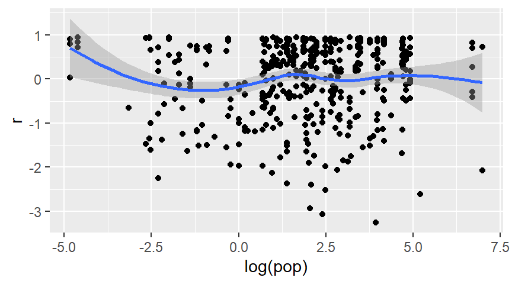

```r
ggplot(leader, aes(log(pop), r)) +
  geom_point()                   +
  geom_smooth(se=TRUE)
```

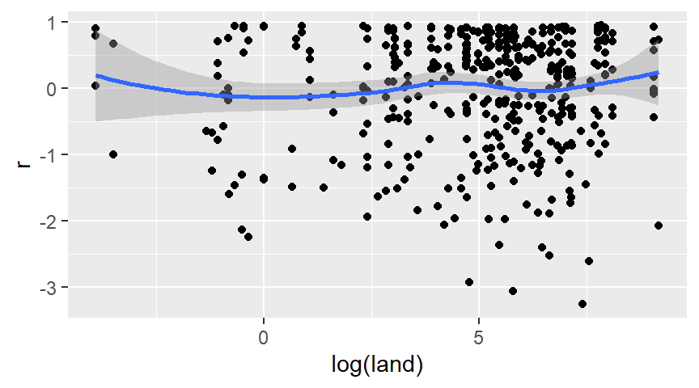

```r
ggplot(leader, aes(log(land), r))     +
  geom_point()                   +
  geom_smooth(se=TRUE)
```

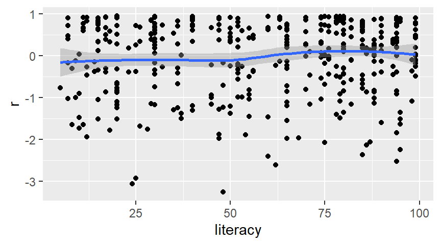

```r
ggplot(leader, aes(literacy, r)) +
  geom_point()                   +
  geom_smooth(se=TRUE)
```

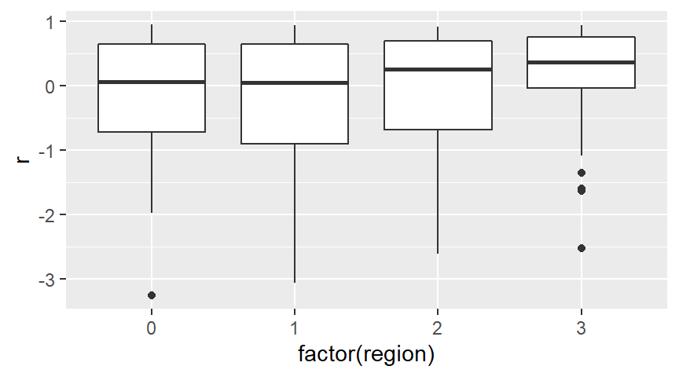

```r
ggplot(leader, aes(factor(region), r))   +
  geom_boxplot()
```

Update your multivariate model

```r
binary_mv2 <-
  coxph(
    binary_surv~
      manner +
      military +
      age +
      loginc +
      region,
    data=leader
  )
summary(binary_mv2)
```

```
## Call:
## coxph(formula = binary_surv ~ manner + military + age + loginc +
##     region, data = leader)
##
##   n= 438, number of events= 327
##
##                                    coef exp(coef) se(coef)      z Pr(>|z|)
## mannernonconstitutional ascent  0.35441   1.42533  0.15454  2.293   0.0218 *
## military                       -0.12335   0.88395  0.15520 -0.795   0.4267
## age                             0.02169   1.02193  0.00515  4.211 2.54e-05 ***
## loginc                         -0.04623   0.95482  0.05450 -0.848   0.3963
## region                          0.25171   1.28622  0.05769  4.363 1.28e-05 ***
## ---
## Signif. codes:  0 '***' 0.001 '**' 0.01 '*' 0.05 '.' 0.1 ' ' 1
##
##                                exp(coef) exp(-coef) lower .95 upper .95
## mannernonconstitutional ascent    1.4253     0.7016    1.0529     1.930
## military                          0.8840     1.1313    0.6521     1.198
## age                               1.0219     0.9785    1.0117     1.032
## loginc                            0.9548     1.0473    0.8581     1.062
## region                            1.2862     0.7775    1.1487     1.440
##
## Concordance= 0.616  (se = 0.019 )
## Likelihood ratio test= 46.22  on 5 df,   p=8e-09
## Wald test            = 44.47  on 5 df,   p=2e-08
## Score (logrank) test = 44.93  on 5 df,   p=1e-08
```

Computet the Schoenfeld residuals to look for non-proportional hazards.

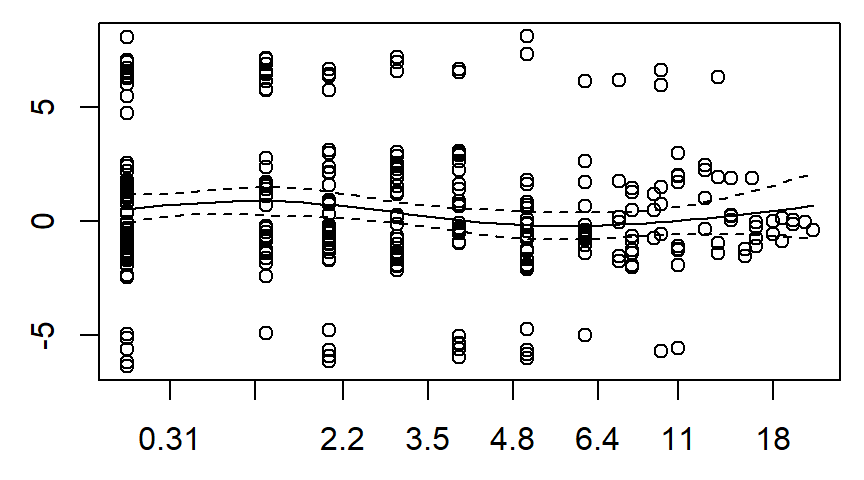

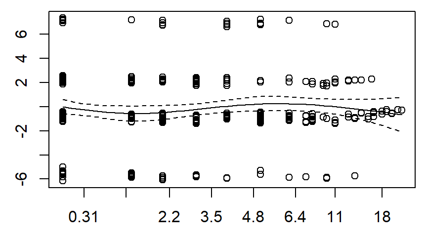

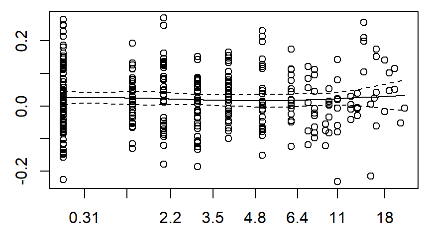

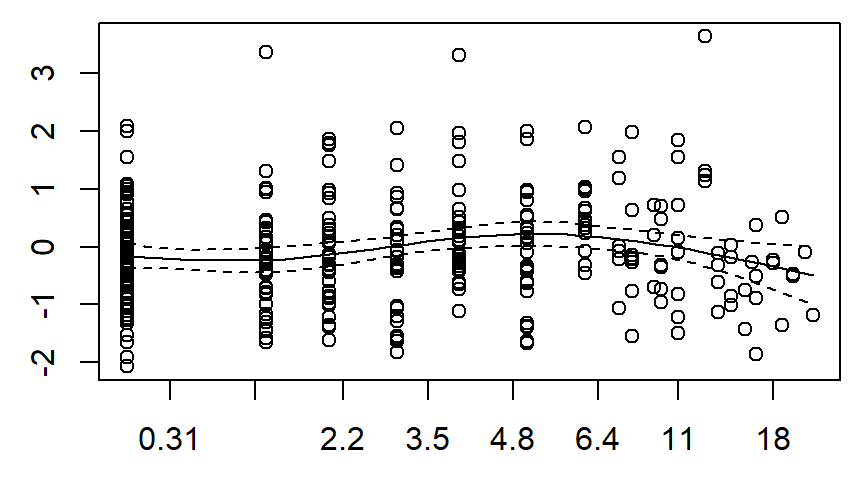

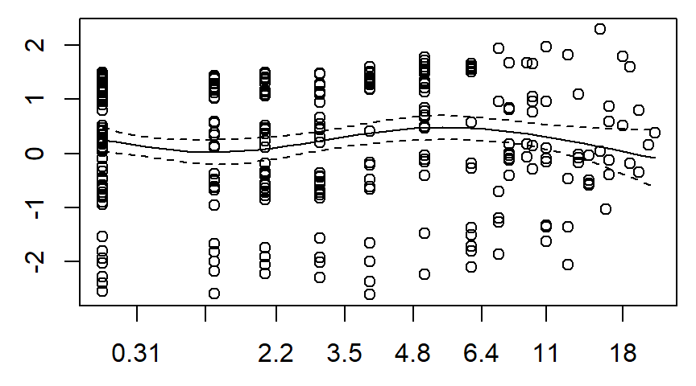

```r
par(mar=c(2.6, 2.6, 0.6, 0.6))
leader_residuals <- cox.zph(binary_mv2)
plot(leader_residuals)
```

## Competing risk models

If there are two or more causes of death and you are interested in developing a model for the individual causes, then you need a competing risk model.

The competing risk model assumes that the overal hazard function, h(t), can be written as

$h(t) = \sum_j h_j(t)$,

where $h_j(t)$ is the hazard function for the jth cause of death.

This implies that the overall cumulative hazard, H(t), is equal to

$H(t) = \sum_j H_j(t)$

where $H_j(t)$ is the cumulative hazard for the jth cause of death.

With a bit of math, you can easily show that the overall cumulative density function, F(t)=1-S(t), can be decomposed into

$F(t) = \sum_j F_j(t)$

where

$F_j(t) = \int_0^t f_j(u) S(u)dt$

Notice that $F_j$ is not a cumulative distribution function. In fact, as t approaches infinity, $F_j(t)$ approaches $P_j$, the probability for the jth cause of death. $F_j$ is called the subdistribution or the cumulative incidence function.

You can estimate $F_j$ with the formula

$\hat{F}_j(t) = \sum_{t_{(i)}<t} \hat{h}_j(t_{(i)}) \hat{S}(t_{(i-1)})$

where $\hat{S}$ is the overall Kaplan-Meier estimate of survival,

$\hat{h}_j(t_{(i)}) = \frac{d_{ij}}{n_i}$,

and $d_{ij}$ and $n_j$ are the number of deaths at time $t_{(i)}$ due to cause j and the number of patients at risk at time $t_{(i)}$.

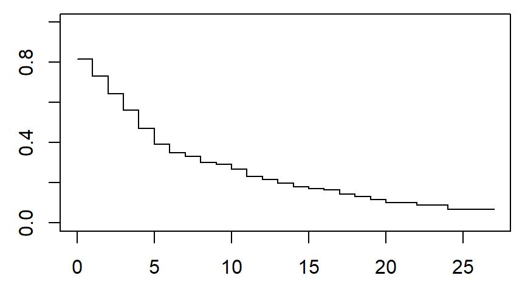

```r
par(mar=c(2.6, 2.6, 0.6, 0.6))
surv_object <-
  Surv(
    leader$years,
    leader$lost,
    type="mstate")

km_overall <- survfit(surv_object~1)
plot(
  km_overall$time,
  km_overall$pstate[ , 1],
  ylim=0:1, type="s")
```

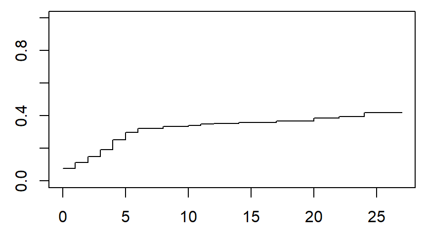

```r
plot(
  km_overall$time,
  km_overall$pstate[ , 2],
  ylim=0:1, type="s")
```

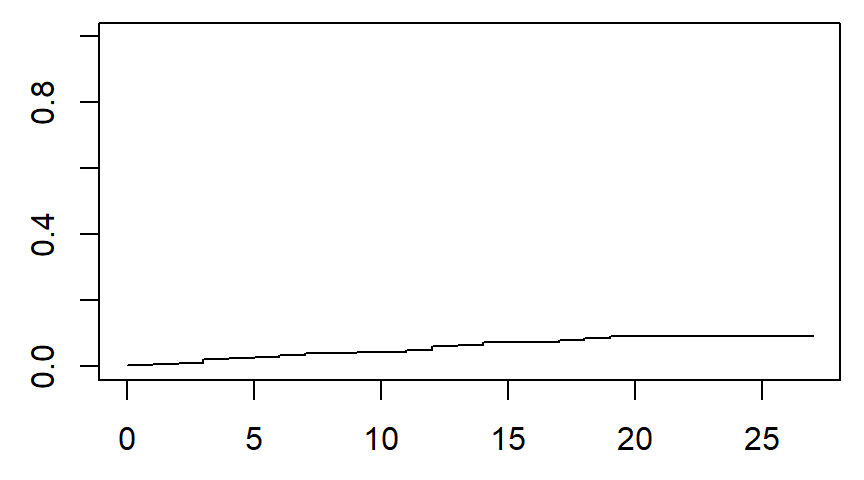

```r
plot(
  km_overall$time,
  km_overall$pstate[ , 3],
  ylim=0:1, type="s")
```

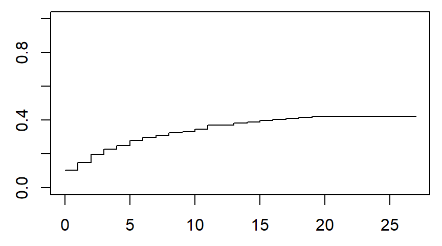

```r
plot(
  km_overall$time,
  km_overall$pstate[ , 4],
  ylim=0:1, type="s")
```

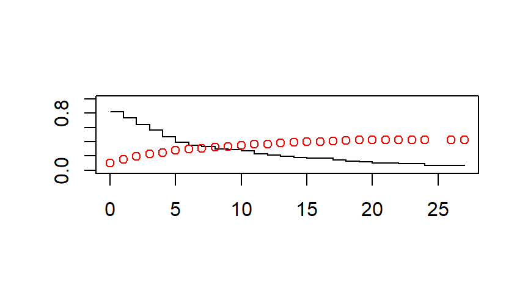

```r
km_single <-
  survfit(
    Surv(
      leader$years,
      leader$lost!="still in power")~1)
plot(km_single, ylim=0:1, conf.int=FALSE)
points(
  km_overall$time,
  km_overall$pstate[ , 4],
  col="red")
```

```r
head(tidy(km_overall))
```

```
## # A tibble: 6 x 9
##    time n.risk n.event n.censor estimate std.error conf.high conf.low state
##   <dbl>  <int>   <int>    <int>    <dbl>     <dbl>     <dbl>    <dbl> <chr>
## 1     0    438       0        7    0.815    0.0186     0.852    0.780 (s0)
## 2     1    350       0       10    0.731    0.0213     0.774    0.691 (s0)
## 3     2    304       0        9    0.642    0.0232     0.689    0.598 (s0)
## 4     3    258       0        8    0.560    0.0242     0.610    0.515 (s0)
## 5     4    217       0        5    0.470    0.0247     0.521    0.424 (s0)
## 6     5    177       0        8    0.393    0.0244     0.444    0.348 (s0)
```

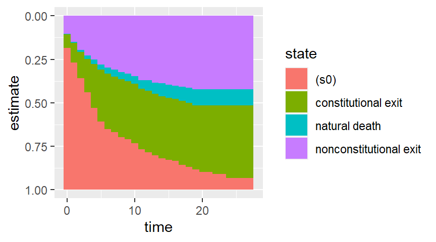

```r
km_overall %>% tidy -> km_overall_tidy
km_overall_tidy %>%
  filter(time==24) %>%
  mutate(time=25) %>%
  bind_rows(km_overall_tidy) -> km_overall_tidy
ggplot(
  data=km_overall_tidy,
  aes(time, estimate, fill=state)) +
  scale_y_reverse()                +
  expand_limits(y=1)               +
  geom_col(width=1)
```

Let’s look at a couple of subsets.

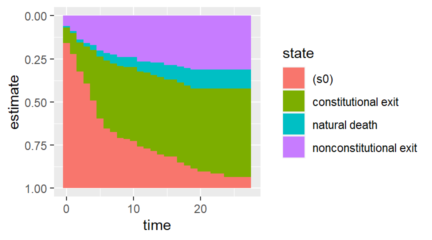

```r
sb1 <- leader$manner=="constitutional ascent"
surv_object <-
  Surv(
    leader$years[sb1],
    leader$lost[sb1],
    type="mstate")

km_sb1 <- survfit(surv_object~1)
km_sb1 %>% tidy -> km_sb1_tidy
km_sb1_tidy %>%
  filter(time==20) %>%
  mutate(time=21) %>%
  bind_rows(km_sb1_tidy) -> km_sb1_tidy
km_sb1_tidy %>%
  filter(time==24) %>%
  mutate(time=25) %>%
  bind_rows(km_sb1_tidy) -> km_sb1_tidy
ggplot(
  data=km_sb1_tidy,
  aes(time, estimate, fill=state)) +
  scale_y_reverse()                +
  expand_limits(y=1)               +
  expand_limits(x=27)              +
  geom_col(width=1)
```

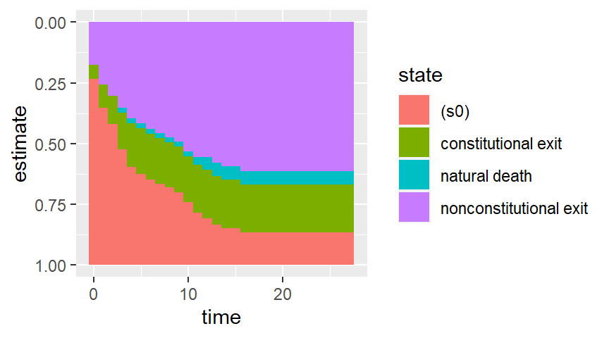

```r
sb2 <- leader$manner=="nonconstitutional ascent"
surv_object <-
  Surv(
    leader$years[sb2],
    leader$lost[sb2],
    type="mstate")
km_sb2 <- survfit(surv_object~1)
km_sb2 %>% tidy -> km_sb2_tidy
for (i in 22:27) {
  km_sb2_tidy %>%
    filter(time==21) %>%
    mutate(time=i) %>%
    bind_rows(km_sb2_tidy) -> km_sb2_tidy
}
ggplot(
  data=km_sb2_tidy,
  aes(time, estimate, fill=state)) +
  scale_y_reverse()                +
  expand_limits(y=1)               +
  expand_limits(x=27)              +
  geom_col(width=1)
```

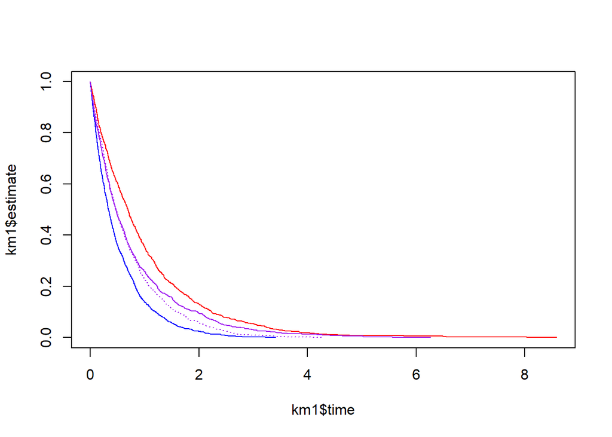

```r
n <- 1000
y1 <- rexp(n, 1)
y2 <- rexp(n, 2)
y3 <- rexp(n, rep(1:2, n/2))
y4 <- rexp(n, 1.5)
cens <- rep(1, n)
km1 <- tidy(survfit(Surv(y1, cens)~1))
km2 <- tidy(survfit(Surv(y2, cens)~1))
km3 <- tidy(survfit(Surv(y3, cens)~1))
km4 <- tidy(survfit(Surv(y4, cens)~1))
plot(km1$time, km1$estimate, type="l", col="red")
lines(km2$time, km2$estimate, col="blue")
lines(km3$time, km3$estimate, col="purple")
lines(km4$time, km4$estimate, col="purple", lty="dotted")
```

Save everything for possible later re-use.

```r
save.image("../bin/survival-lecture-6.RData")
```